# 607_Assignment2

Ariann Chai

2023-09-08

## Introduction

For my Assignment 2, I choose to collect movie ratings from my friends for the last 6 Marvel movies. I am a big Marvel fan and figured this would be an good list of movies for my friends. (of course there was still some null values to deal with).

The last 6 Marvel movies were  
- Spiderman 3: No Way Home  
- Doctor Strange 2: Multiverse of Madness  
- Black Panther 2: Wakanda Forever  
- Thor 4: Love and Thunder  
- Antman and the Wasp 3: Quantumania  
- Guardian of the Galaxy Vol. 3

I got data from 8 of my friends and added it to a table on mySQL. I used the mySQL library and dbconnect in order to access the table with the code below. Since the password had to be erased, this code will not be 100% rerunnable.

```
install.packages("RMySQL")
library(RMySQL)

mysqlconnection = dbConnect(RMySQL::MySQL(),
                            dbname='607_Assignment2',
                            host='localhost',
                            port=3306,
                            user='root',
                            password='')
```

The table was then access and set in a dataframe.

```
result = dbSendQuery(mysqlconnection, "select * from moviesRating")
moviesRating = fetch(result)
moviesRating
```

For the purpose of this rmarkdown and to make this runnable, I saved the select query into a csv.

```r
library(readr)
moviesRating <- read_csv("moviesRating.csv")
```

```
## ──────────────────────────────────────────────────────── Delimiter: "," dbl
## (8): ...1, id, SpidermanNWH, DrStrange2, BlackPanther2, Thor4, Antman3, ...
```

```r
#clean up the data and set it as a simple dataframe (like it would be if I got it directly from mysql)
moviesRating <- subset(moviesRating, select=c(2,3,4,5,6,7,8))
moviesRating = as.data.frame(moviesRating)

moviesRating
```

```
##   id SpidermanNWH DrStrange2 BlackPanther2 Thor4 Antman3 GOTG3
## 1  1           NA          4             4     2       2     5
## 2  2           NA          4             4     3       2     5
## 3  3            3          3             4     1       2     3
## 4  4            4          3             5     3      NA    NA
## 5  5            5          2             2     1       1     4
## 6  6            5          3             4     3       2     4
## 7  7            4          3             4     2       3     4
## 8  8            5          3             4     1       2     5
```

## Dealing with null values

For the 8 people I surveyed, there was 4 null values where the person did not see that specific movie to be able to review it. It was important to fill in the null values so that each movie was being graded with the same amount of scores. In order to do this, I took the average of that movie’s scores from the non-null values and used that as the fill in. Since it is already the average score with non-null values for that movie, it will not have an effect on the average score with non-null and null values.

i.e. if I have a [2,4,4,3,2,null], without the null, the average is 3.  
(2+4+4+3+2=15/5=3)  
So if I replace the null with a 3, the average is still 3.  
(2+4+4+3+2+3=18/6=3)

To deal with this, I wrote a for loop that will go through each column, stop at the columns with null values, replace the nulls in that column with the average from the non-null values, and round the values to the first decimal place. (I rounded to the first decimal place keep the number neat for this assignment.)

```r
moviesRatingclean <- moviesRating
for(i in 1:ncol(moviesRatingclean)) {
  if (any(is.na(moviesRatingclean[ ,i]))){
    moviesRatingclean[ ,i][is.na(moviesRating[ ,i])] <- mean(moviesRatingclean[ ,i], na.rm=TRUE)
    moviesRatingclean[ ,i]=round(moviesRatingclean[ ,i],1)
    }
}

moviesRatingclean
```

```
##   id SpidermanNWH DrStrange2 BlackPanther2 Thor4 Antman3 GOTG3
## 1  1          4.3          4             4     2       2   5.0
## 2  2          4.3          4             4     3       2   5.0
## 3  3          3.0          3             4     1       2   3.0
## 4  4          4.0          3             5     3       2   4.3
## 5  5          5.0          2             2     1       1   4.0
## 6  6          5.0          3             4     3       2   4.0
## 7  7          4.0          3             4     2       3   4.0
## 8  8          5.0          3             4     1       2   5.0
```

## Graphs and conclusions

Below are a series of graphs I used to analyze and come up with conclusions for my data. The code I used to find this data and graph them are also included.

```r
library(ggplot2)
```

This first graph shows the number of ratings with values vs ratings with null values for the whole dataframe. This graph can be use to show the reliability of the dataset and how well we can deal with the null values. It is inevitable that we will have some null values. Since we are using the non-null values to create a substitute for the null values (explained in the above section “Dealing with null values”), we would like to have more non-null values than null values.

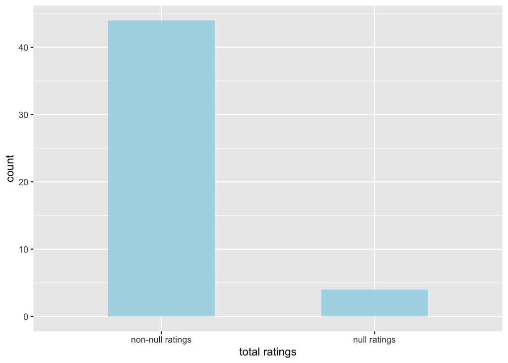

```r
totalnulls <- data.frame(nulls=c("null ratings", "non-null ratings"), count=c(0, 0))

totalnulls[1,2]=sum(is.na(moviesRating))
totalnulls[2,2]=((ncol(moviesRating)-1)*nrow(moviesRating)-sum(is.na(moviesRating)))

ggplot(data=totalnulls, aes(x=nulls,y=count))+geom_bar(stat="identity", width=0.5,fill="lightblue")+xlab("total ratings")
```

This data shows that we have 44 non-null ratings vs 4 null ratings so we have a 91.6666667`% completed dataset.

This second graph shows the number of movies that had some null values vs those without any null values. Oddly enough, the data comes out split in half with 3 completely rated movies vs 3 missing ratings movies.

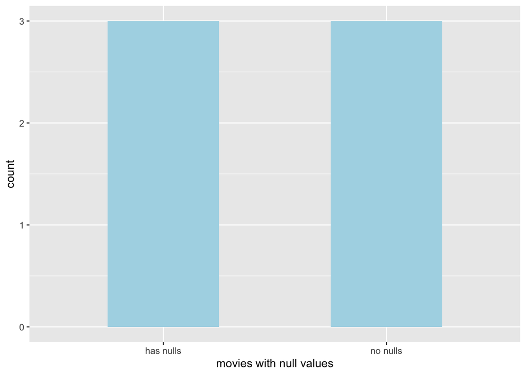

```r
nullvsnonnull <- data.frame(nulls=c("has nulls", "no nulls"), count=c(0, 0))

for(i in 2:ncol(moviesRating)) {
  if (any(is.na(moviesRating[ ,i]))){
    nullvsnonnull[1,-1] = (nullvsnonnull[1,-1]+1)
  }else{
    nullvsnonnull[2,-1] = (nullvsnonnull[2,-1]+1)
  }
}
ggplot(data=nullvsnonnull, aes(x=nulls,y=count))+geom_bar(stat="identity", width=0.5,fill="lightblue")+xlab("movies with null values")
```

This third graph also shows us null values, but this time for specific movies. It points out which 3 movies were not seen by all the raters. It appears the 3 movies are the first movie and the last 2 movies to come out of this set. The last 2 movies could indicate that people don’t necessarily watch these movies as soon as they come out and tend to wait a bit.

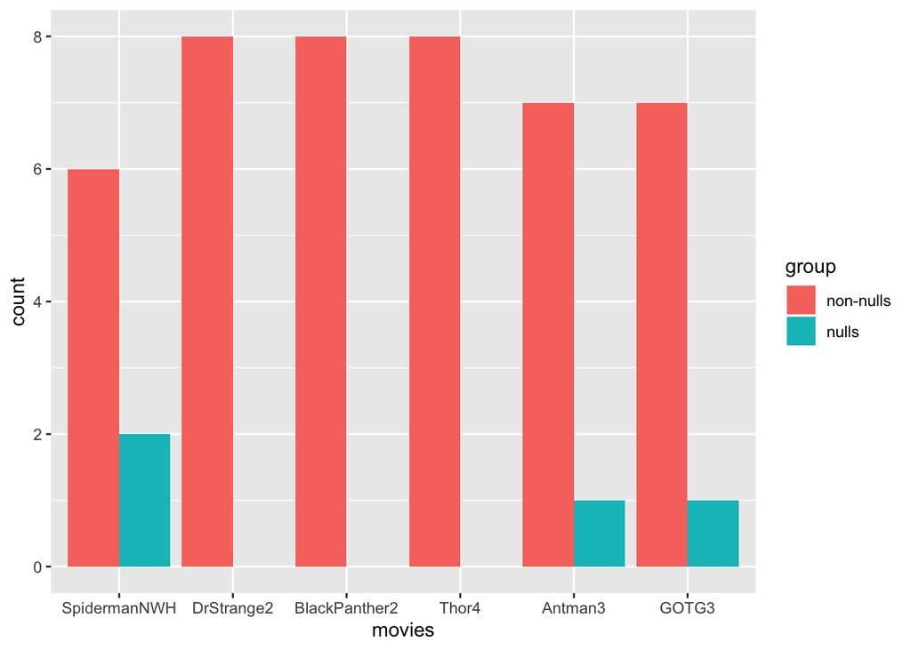

```r
sum = nrow(moviesRating)
movieNull <- data.frame(group=rep(c("nulls","non-nulls"),each=6),
                        movies=rep(c("SpidermanNWH", "DrStrange2", "BlackPanther2", "Thor4", "Antman3", "GOTG3")),
                        count=c(0,0,0,0,0,0,sum,sum,sum,sum,sum,sum))

for(i in 2:ncol(moviesRating)) {
  movieNull[(i-1),3] = sum(is.na(moviesRating[i]))
  movieNull[(i+5),3] = (sum-sum(is.na(moviesRating[i])))
}

ggplot(movieNull, aes(x=factor(movies,level=c("SpidermanNWH", "DrStrange2", "BlackPanther2", "Thor4", "Antman3", "GOTG3")),y=count,fill=group))+
  geom_bar(stat="identity",position=position_dodge()) + xlab("movies")
```

The last bar graph shows the average scores for each movie. Below is the code I used to make a new dataframe to hold the average scores and the printed dataframe with the full average numbers on it.

```r
moviesMean <- data.frame(movies=rep(c("SpidermanNWH", "DrStrange2", "BlackPanther2", "Thor4", "Antman3", "GOTG3")),
                      averages=c(0,0,0,0,0,0))

moviesMean[1,2]=mean(moviesRatingclean$SpidermanNWH)
moviesMean[2,2]=mean(moviesRatingclean$DrStrange2)
moviesMean[3,2]=mean(moviesRatingclean$BlackPanther2)
moviesMean[4,2]=mean(moviesRatingclean$Thor4)
moviesMean[5,2]=mean(moviesRatingclean$Antman3)
moviesMean[6,2]=mean(moviesRatingclean$GOTG3)

moviesMean
```

```
##          movies averages
## 1  SpidermanNWH   4.3250
## 2    DrStrange2   3.1250
## 3 BlackPanther2   3.8750
## 4         Thor4   2.0000
## 5       Antman3   2.0000
## 6         GOTG3   4.2875
```

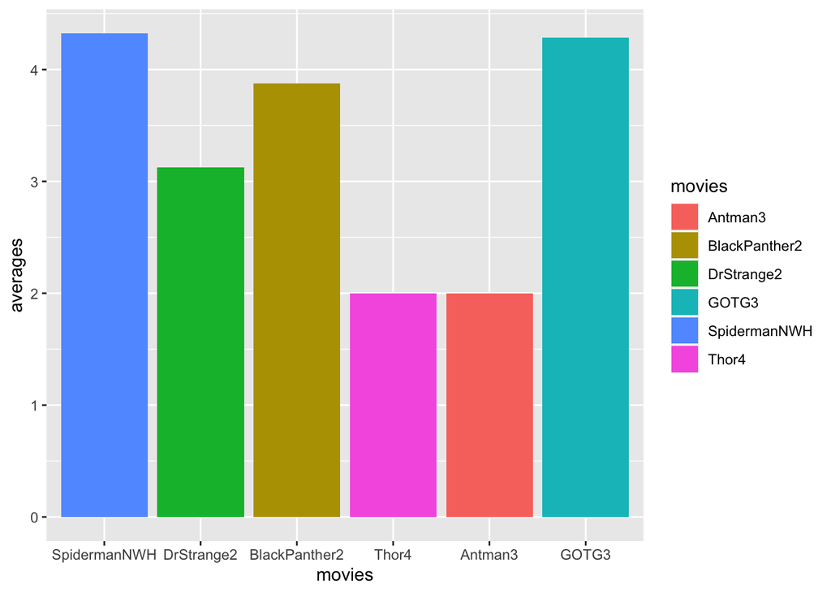

```r
ggplot(data = moviesMean, aes(x=factor(movies,level=c("SpidermanNWH", "DrStrange2", "BlackPanther2", "Thor4", "Antman3", "GOTG3")), y = averages,fill=movies)) +
  geom_bar(stat="identity") + xlab("movies")
```

The highest rated movie was SpidermanNWH with a average rating of 4.325.  
While the lowest rated movies were Thor4 and Antman3 with a average rating of 2.

(I am actually one of the people who gave SpidermanNWH a null cause I have not seen it yet.)